# PM 566 Final Project: Analysing Vaccine Preventable Diseases and Vaccine Hesitancy in California

University of Southern California, Fall 2024

Author

Kendall Dimson

## Introduction

Long since the rollout of the polio vaccine, there have been a variety of vaccines created in the 1900s to present-day that have been influential in the epidemiological shift, with vaccine efficiency as one of the main modes of primary prevention in infectious disease epidemiology. However, despite continuous efforts to vaccinate, many Vaccine-Preventable diseases are prevalent to this day that threaten the public health system. As a result, in the modern era there have been several vaccine-preventable epidemics that have occurred. According to the Center for Disease Control and Prevention, epidemics are defined as the occurrence of more cases of disease than expected in a given area or among a specific group of people over a particular period of time. There are various factors that can influence the occurrence of these epidemics, including vaccination rates and vaccine hesitancy. This project serves to conduct a comprehensive exploratory analysis into vaccine-preventable diseases in California, with specific focus on three: Whooping cough (Pertussis), Invasive Meningococcal Disease, COVID-19.

Various research questions include:

When and where did previous Pertussis epidemics occur in California?

What was the statewide trend for Invasive Meningococcal Disease incidence?

How did COVID-19 era vaccine hesitancy impact California counties? Is there an association between vaccine hesitancy and previous Vaccine-Preventable Disease incidence?

## Methods

In the data cleaning and wrangling step, counties that recorded 0 cases of a disease were removed. Variety of subsetted datasets were created, subsetting into “california” and “county” datasets since there are some categories in the “County” variable that have a summation number of diseases in California. For each, the filter() function subset. The kable() function was used to print a table of the total number of vaccine preventable diseases reported in the entirety of the dataset. The arrange() function was used to print the top five vaccine-reportable diseases with highest cumulative incidence, as well as to print the top five counties of each disease. Ggplot barplots were used to visualize trends in incidence counts. To analyze the distribution of pertussis cases by counties, I used the leaflet package to code an interactive bubble map, normalized by population density. To visually analyze vaccine hesitancy association, leaflet heat maps were utilized. In the analysis on Pertussis, the data was stratified to compare annual incidence in each California county. In the analysis on Invasive Meningococcal Disease, the data was stratified to visualize bar graphs. All data was analyzed using R software Version 2024.04.2+764.

## Results

Table 1. Total Cases of Vaccine-Preventable Diseases Reported in California, 2001-2022

| Disease | Total Cases |
| --- | --- |
| Pertussis | 57219 |
| Hepatitis B, Chronic | 4462 |
| Hepatitis A | 3035 |
| Invasive Meningococcal Disease | 2718 |
| Hepatitis B, Acute | 1349 |
| Mumps | 1108 |
| Hepatitis C, Acute | 1050 |
| Measles | 521 |
| Varicella Hospitalizations | 406 |
| Varicella Hospitalization/Death | 93 |
| Tetanus | 86 |
| Rubella | 9 |
| Diphtheria | 2 |

There were a total of 72,058 incident vaccine preventable cases recorded. The top five in total cases reported were Pertussis (n=57,219), Hepatitis B, chronic (n=4462) and acute (n=1349), Invasive Meningococcal Disease (n=2718), and Hepatitis A (n=3035).

```r
# EDA

#Remove counties that reported 0 cases in a year
vaccine <- vaccine |> filter(Count != 0)

#Check count of disease categories in the dataset
vaccine |>
  count(Disease, sort=TRUE)
```

```
# A tibble: 15 × 2
   Disease                                              n
   <chr>                                            <int>
 1 Pertussis                                          979
 2 Invasive Meningococcal Disease                     622
 3 Hepatitis A                                        391
 4 Hepatitis B, Acute                                 285
 5 Hepatitis C, Acute                                 259
 6 Mumps                                              213
 7 Measles                                            169
 8 Varicella Hospitalizations                         142
 9 Hepatitis B, Chronic                                95
10 Tetanus                                             93
11 Varicella Hospitalization/Death                     45
12 Rubella                                             14
13 Diphtheria                                           4
14 Haemophilus influenzae (invasive), all serotypes     4
15 Hepatitis B, Perinatal                               4
```

```r
#Checked for any missing values or irregularities
#summary(vaccine)

#Total number of cases in dataset, stratify by counties, states overall, and top 5 diseases
county <- vaccine |> filter (County != 'California')
california <- vaccine |> filter (County == 'California')

#summations, each year
#table(vaccine$Year)
#sum(county$Count)

dim(county)
```

```
[1] 3157    5
```

```r
head(county)
```

```
# A tibble: 6 × 5
  `_id` Disease     County   Year Count
  <dbl> <chr>       <chr>   <dbl> <dbl>
1    22 Diphtheria  Alameda  2022     1
2  1234 Diphtheria  Ventura  2002     1
3  1303 Hepatitis A Alameda  2011     6
4  1304 Hepatitis A Alameda  2012     3
5  1305 Hepatitis A Alameda  2013     7
6  1306 Hepatitis A Alameda  2014     9
```

```r
tail(county)
```

```
# A tibble: 6 × 5
  `_id` Disease                    County    Year Count
  <dbl> <chr>                      <chr>    <dbl> <dbl>
1 10946 Varicella Hospitalizations Tulare    2014     1
2 10948 Varicella Hospitalizations Tulare    2016     1
3 10954 Varicella Hospitalizations Tuolumne  2013     1
4 10966 Varicella Hospitalizations Ventura   2016     2
5 10970 Varicella Hospitalizations Yolo      2011     1
6 10983 Varicella Hospitalizations Yuba      2015     1
```

```r
str(county)
```

```
spc_tbl_ [3,157 × 5] (S3: spec_tbl_df/tbl_df/tbl/data.frame)
 $ _id    : num [1:3157] 22 1234 1303 1304 1305 ...
 $ Disease: chr [1:3157] "Diphtheria" "Diphtheria" "Hepatitis A" "Hepatitis A" ...
 $ County : chr [1:3157] "Alameda" "Ventura" "Alameda" "Alameda" ...
 $ Year   : num [1:3157] 2022 2002 2011 2012 2013 ...
 $ Count  : num [1:3157] 1 1 6 3 7 9 6 9 15 11 ...
 - attr(*, "spec")=
  .. cols(
  ..   `_id` = col_double(),
  ..   Disease = col_character(),
  ..   County = col_character(),
  ..   Year = col_double(),
  ..   Count = col_double()
  .. )
 - attr(*, "problems")=<externalptr>
```

```r
summary(county)
```

```
      _id          Disease             County               Year
 Min.   :   22   Length:3157        Length:3157        Min.   :2001
 1st Qu.: 2961   Class :character   Class :character   1st Qu.:2009
 Median : 4744   Mode  :character   Mode  :character   Median :2014
 Mean   : 5320                                         Mean   :2013
 3rd Qu.: 7495                                         3rd Qu.:2018
 Max.   :10983                                         Max.   :2022
     Count
 Min.   :   1.00
 1st Qu.:   1.00
 Median :   3.00
 Mean   :  22.82
 3rd Qu.:  10.00
 Max.   :2206.00
```

```r
#No issues found in data irregularities. Year and Count variables numeric. Disease & County variables are character class. _id variable is irrelevant in this analysis.}
```

```r
hav <- county |> filter (Disease == 'Hepatitis A') |> filter (County != 'Los Angeles')
hav |> arrange(desc(Count))
```

```
# A tibble: 367 × 5
   `_id` Disease     County          Year Count
   <dbl> <chr>       <chr>          <dbl> <dbl>
 1  1753 Hepatitis A San Diego       2017   585
 2  1837 Hepatitis A Santa Cruz      2017    77
 3  1749 Hepatitis A San Diego       2013    40
 4  1743 Hepatitis A San Bernardino  2019    39
 5  1748 Hepatitis A San Diego       2012    38
 6  1754 Hepatitis A San Diego       2018    35
 7  1758 Hepatitis A San Diego       2022    30
 8  1708 Hepatitis A Riverside       2020    28
 9  1668 Hepatitis A Orange          2016    26
10  1752 Hepatitis A San Diego       2016    26
# ℹ 357 more rows
```

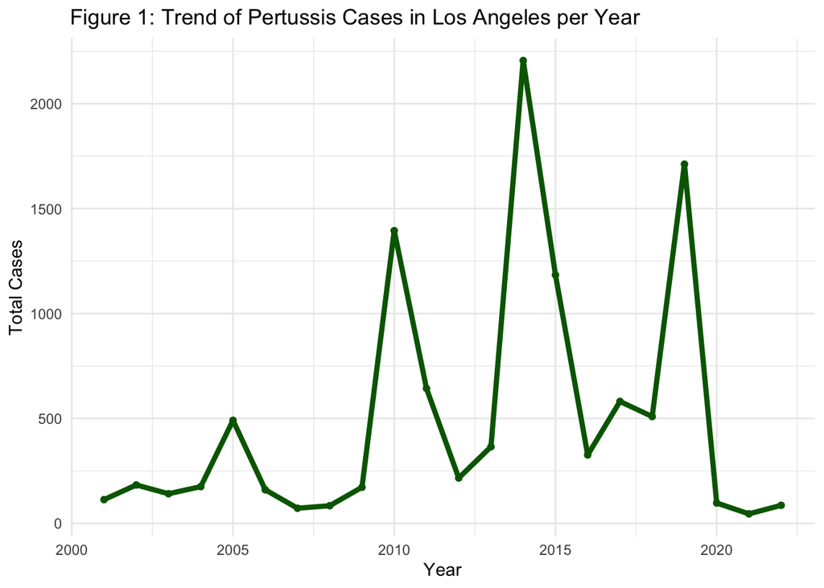

In Figure 1, we investigated the trend of Pertussis cases in Los Angeles each year, the county who had the most cumulative incidence for Pertussis. It was found that Los Angeles county had peaks of case incidence in 2010, 2014, and 2019. After 2020 there was a lower decline of Pertussis cases, but this is likely due to the occurrence of the COVID-19 pandemic.

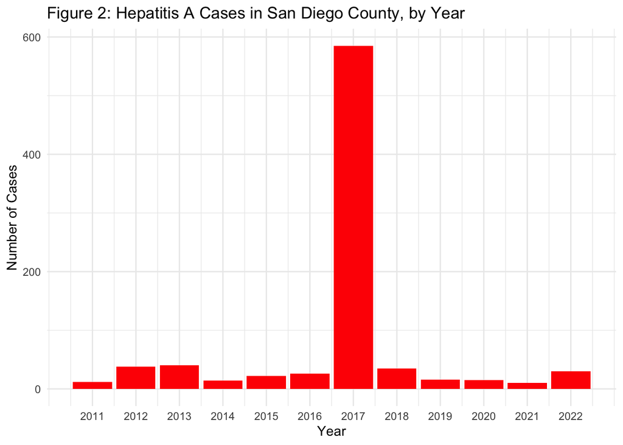

```r
library(knitr)
library(readr)
library(dplyr)
library(ggplot2)
library(tidyverse)

hav <- county |> filter (Disease == 'Hepatitis A')
#Stratify HAV, Check San Diego Trend
hav_sd <- hav |>
  filter(County == 'San Diego')

ggplot(hav_sd, aes(x = Year, y = Count)) +
  geom_bar(stat = "identity", fill = "red") +
  labs(title = "Figure 2: Hepatitis A Cases in San Diego County, by Year",
       x = "Year",
       y = "Number of Cases") +
  scale_x_continuous(breaks = seq(min(hav_sd$Year), max(hav_sd$Year), by = 1)) +
  theme_minimal()
```

In Figure 2, it was identified of a Hepatitis A epidemic in San Diego, which greatly stood out from its trend of lower case incidence in recent years. After further research, it was found that the epidemic lasted only one year due to San Diego county’s response efforts in vaccination, distribution of hygeine kits, and education.

```r
hesitant <- read_csv("~/Desktop/Vaccine_Hesitancy_for_COVID-19__County_and_local_estimates_20241206.csv")
hesitant <- hesitant |> filter(State=='CALIFORNIA')

#Convert proportions to percentages
hesitant$`Estimated strongly hesitant`<- hesitant$`Estimated strongly hesitant` * 100

hesitant$`Estimated hesitant` <- hesitant$`Estimated hesitant` * 100

hesitant$`Estimated hesitant or unsure`<- hesitant$`Estimated hesitant or unsure` * 100

hesitant$`Percent adults fully vaccinated against COVID-19 (as of 6/10/21)` <- hesitant$`Percent adults fully vaccinated against COVID-19 (as of 6/10/21)` *100

hesitant$`Percent Hispanic`<- hesitant$`Percent Hispanic`*100

hesitant$`Percent non-Hispanic American Indian/Alaska Native`<- hesitant$`Percent non-Hispanic American Indian/Alaska Native`*100

hesitant$`Percent non-Hispanic White` <- hesitant$`Percent non-Hispanic White`*100

hesitant$`Percent non-Hispanic Asian`<- hesitant$`Percent non-Hispanic Asian`*100

hesitant$`Percent non-Hispanic Black` <- hesitant$`Percent non-Hispanic Black`*100

hesitant$`Percent non-Hispanic Native Hawaiian/Pacific Islander`<- hesitant$`Percent non-Hispanic Native Hawaiian/Pacific Islander`*100

hesitant_data <- hesitant %>%
  filter(State == 'CALIFORNIA') %>%
  select(
    `County Name`,
    `Percent Hispanic`,
    `Percent non-Hispanic American Indian/Alaska Native`,
    `Percent non-Hispanic White`,
    `Percent non-Hispanic Asian`,
    `Percent non-Hispanic Black`,
    `Percent non-Hispanic Native Hawaiian/Pacific Islander`,
    `Estimated strongly hesitant`,
    `Estimated hesitant`,
    `Estimated hesitant or unsure`,
    `Percent adults fully vaccinated against COVID-19 (as of 6/10/21)`
  ) %>%
  rename(
    County = `County Name`,
    Hispanic_Percentage = `Percent Hispanic`,
    Non_Hispanic_American_Indian_Alaska_Native = `Percent non-Hispanic American Indian/Alaska Native`,
    Non_Hispanic_White = `Percent non-Hispanic White`,
    Non_Hispanic_Asian = `Percent non-Hispanic Asian`,
    Non_Hispanic_Black = `Percent non-Hispanic Black`,
    Non_Hispanic_Native_Hawaiian_Pacific_Islander = `Percent non-Hispanic Native Hawaiian/Pacific Islander`,
    Strongly_Hesitant_Percentage = `Estimated strongly hesitant`,
    Hesitant_Percentage = `Estimated hesitant`,
    Hesitant_or_Unsure_Percentage = `Estimated hesitant or unsure`,
    Fully_Vaccinated_Percentage = `Percent adults fully vaccinated against COVID-19 (as of 6/10/21)`
  )
```

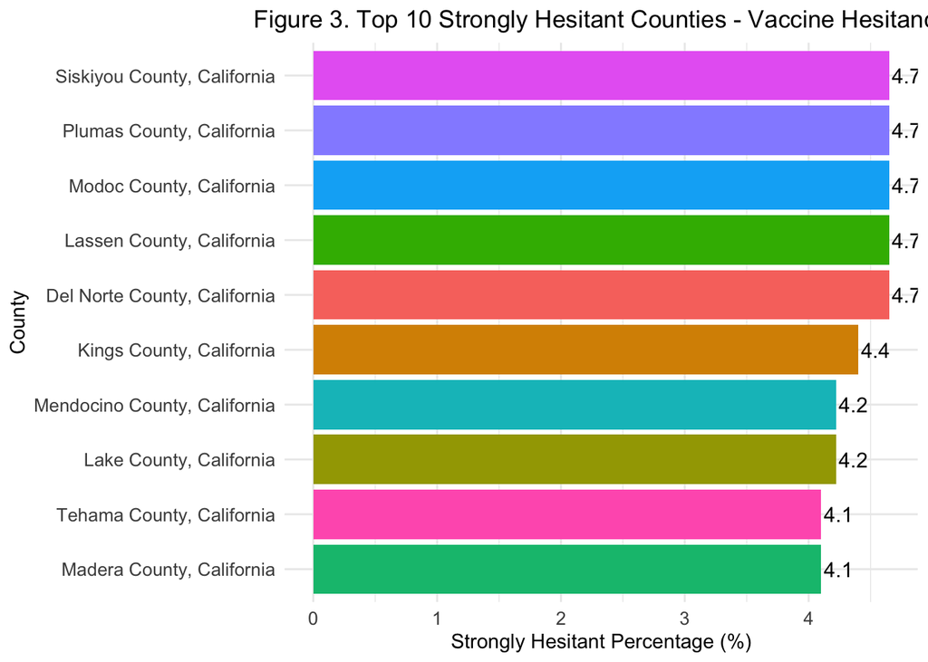

```r
# Graph 1: Top 10 Strongly Hesitant Counties (Horizontal Bar Graph)

top_10_strongly_hesitant <- hesitant |>
  arrange(desc(`Estimated strongly hesitant`)) |>
  head(10)

ggplot(top_10_strongly_hesitant, aes(x = `Estimated strongly hesitant`,
                                     y = reorder(`County Name`, `Estimated strongly hesitant`),
                                     fill = `County Name`)) +
  geom_bar(stat = "identity", show.legend = FALSE) +
  geom_text(aes(label = round(`Estimated strongly hesitant`, 1)),
            hjust = -0.1, size = 4) +  # Place labels inside bars
  labs(title = "Figure 3. Top 10 Strongly Hesitant Counties - Vaccine Hesitancy",
       x = "Strongly Hesitant Percentage (%)",
       y = "County") +
  theme_minimal() +
  theme(axis.text.y = element_text(size = 10),
        axis.text.x = element_text(size = 10),
        plot.title = element_text(hjust = 0.5))
```

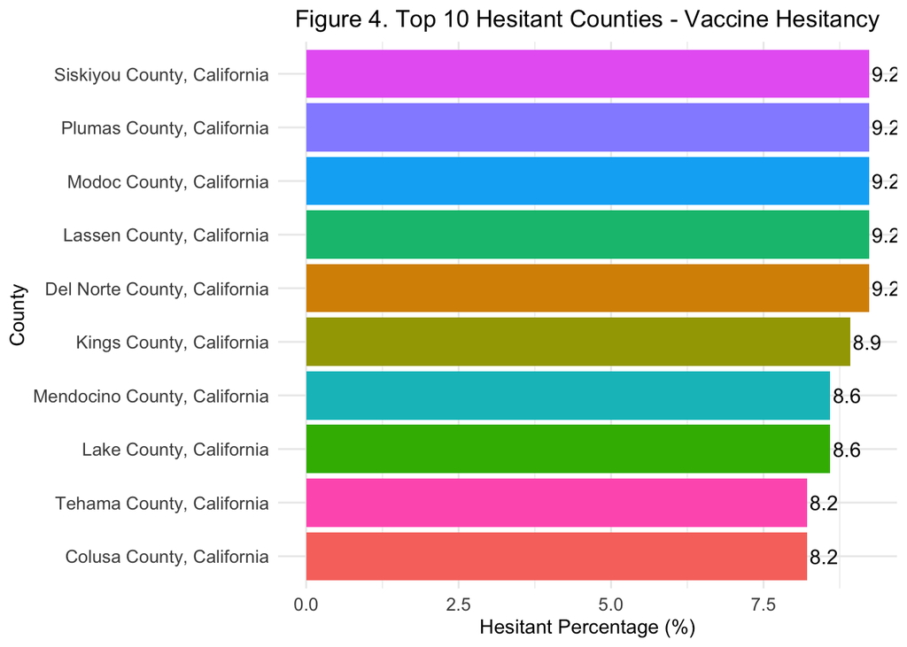

```r
# Graph 2: Top 10 Hesitant Counties (Horizontal Bar Graph)

top_10_hesitant <- hesitant %>%
  arrange(desc(`Estimated hesitant`)) %>%
  head(10)

ggplot(top_10_hesitant, aes(x = `Estimated hesitant`,
                            y = reorder(`County Name`, `Estimated hesitant`),
                            fill = `County Name`)) +
  geom_bar(stat = "identity", show.legend = FALSE) +
  geom_text(aes(label = round(`Estimated hesitant`, 1)),
            hjust = -0.1, size = 4) +
  labs(title = "Figure 4. Top 10 Hesitant Counties - Vaccine Hesitancy",
       x = "Hesitant Percentage (%)",
       y = "County") +
  theme_minimal() +
  theme(axis.text.y = element_text(size = 10),
        axis.text.x = element_text(size = 10),
        plot.title = element_text(hjust = 0.5))
```

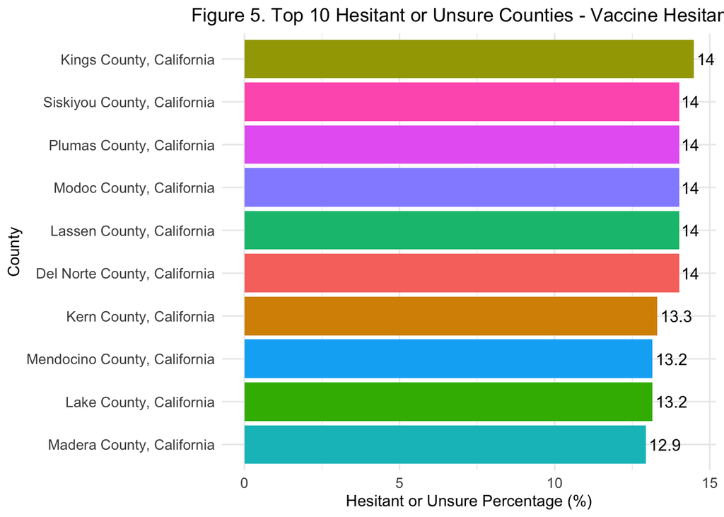

```r
# Graph 3: Top 10 Hesitant or Unsure Counties (Horizontal Bar Graph)

top_10_hesitant_unsure <- hesitant|>
  arrange(desc(`Estimated hesitant or unsure`)) |>
  head(10)

ggplot(top_10_hesitant_unsure, aes(x = `Estimated hesitant or unsure`,
                                   y = reorder(`County Name`, `Estimated hesitant or unsure`),
                                   fill = `County Name`)) +
  geom_bar(stat = "identity", show.legend = FALSE) +
  geom_text(aes(label = round(`Estimated hesitant or unsure`, 1)),
            hjust = -0.1, size = 4) +
  labs(title = "Figure 5. Top 10 Hesitant or Unsure Counties - Vaccine Hesitancy",
       x = "Hesitant or Unsure Percentage (%)",
       y = "County") +
  theme_minimal() +
  theme(axis.text.y = element_text(size = 10),  # Adjust y-axis text size
        axis.text.x = element_text(size = 10),  # Adjust x-axis text size
        plot.title = element_text(hjust = 0.5))  # Center title
```

Interestingly, in Figures 3, 4 and 5, there was overlap in the California counties that were surveyed with highest percentage of vaccine hesitancy in the state. This included: Siskiyou County, Plumas County, Kings County, and Modoc County as some of the few that stood out in the overlap. However, one of the limitations that was found in this approach is that the percentages of vaccine hesitancy may be too low to capture an appropriate trend nor association. For the survey answer of “strongly hesitant,” the highest percentage was in Siskiyou County with 4.7%, which is still a lower percentage. The highest percentage of “hesitant or unsure” in hesitancy was 14% in Kings, Siskiyou, Plumas, Modoc, Lassen, and Del Norte County.